# Time Series Homework: Chapter 4 Lesson 2

Tristan Farrow

### Revision

I added to my comments.

## Questions

### Question 1 - Random Walks: Stocks (30 points)

Modify the [code used to get the prices of McDonald’s stock](https://byuistats.github.io/timeseries/chapter_4_lesson_2.html#differencing) to download closing stock prices for a different publicly-traded company over a time period of your choice.

#### a) Create a time plot of the daily closing stock prices.

**Answer**

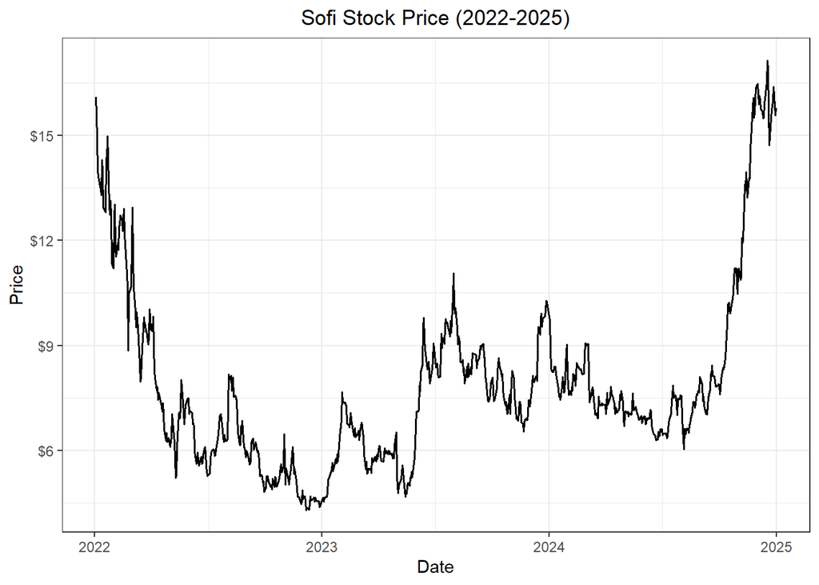

```r
symbol <- "SOFI"
company <- "Sofi Technologies"
date_start <- "2022-01-01"
date_end <- "2025-01-01"

# Fetch stock prices (can be used to get new data)
stock_df <- tq_get(symbol, from = date_start, to = date_end, get = "stock.prices")

# Transform data into tsibble
stock_ts <- stock_df %>%
  mutate(
    dates = date,
    value = adjusted
  ) %>%
  dplyr::select(dates, value) %>%
  as_tibble() %>%
  arrange(dates) |>
  mutate(diff = value - lag(value)) |>
  as_tsibble(index = dates, key = NULL)

ggplot(
  data = stock_df,
  aes(x = date, y = open)
) +
  geom_line(linewidth = .7) +
  labs(
    title = "Sofi Stock Price (2022-2025)",
    x = "Date",
    y = "Price"
  ) +
  scale_y_continuous(
    labels = scales::label_dollar()
  ) +
  theme_bw() +
  theme(
    plot.title = element_text(hjust = 0.5)
  )
```

#### b) Create a correlogram of the daily closing stock prices. Is there evidence that daily closing stock prices follows a random walk? Please explain.

**Answer**

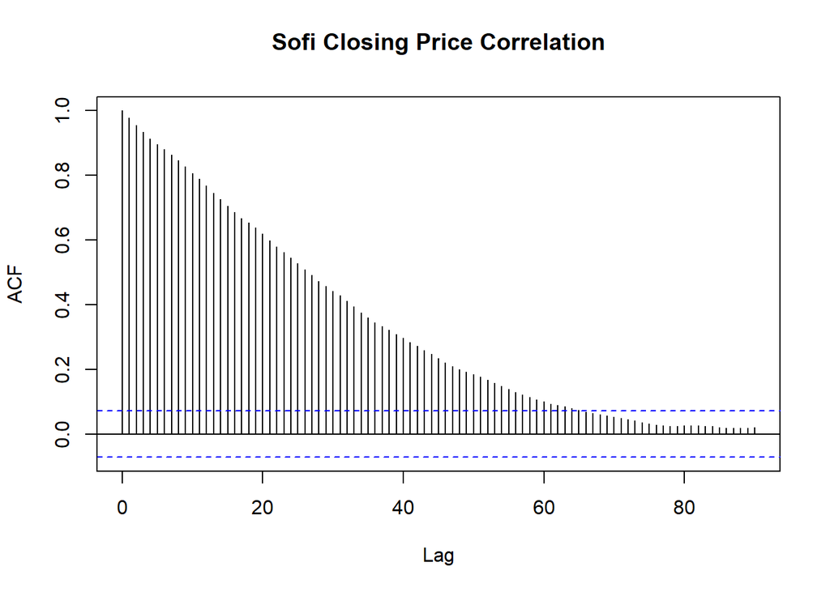

```r
acf(stock_df$close, plot = TRUE, type = "correlation", lag.max = 90,
    main = "Sofi Closing Price Correlation")
```

The correlogram gives strong evidence of a random walk. It shows that a day’s closing price is highly correlated with the days prior to it and slowly fades over time. The slow decay is normal in non-stationary time series like a random walk.

#### c) Take the first difference of your daily closing stock prices and plot the resulting time series.

**Answer**

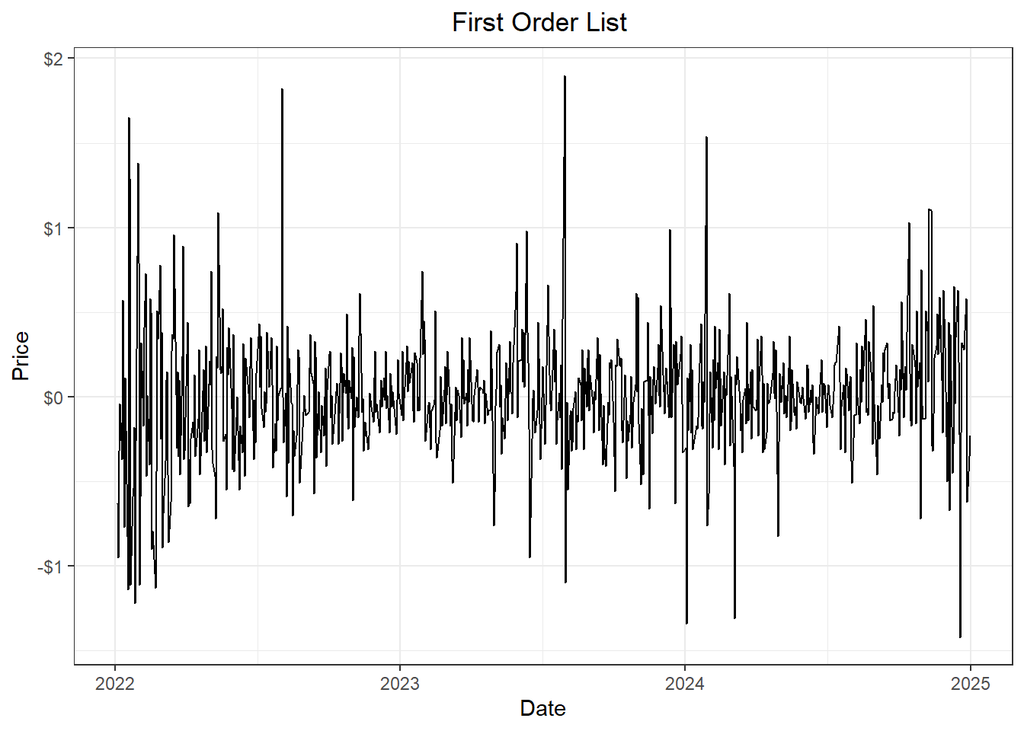

```r
ggplot(
  data = stock_ts,
  aes(x = dates, y = diff)
) +
  geom_line() +
  labs(
    title = "First Order List ",
    x = "Date",
    y = "Price"
  ) +
  scale_y_continuous(
    labels = scales::label_dollar()
  ) +
  theme_bw() +
  theme(
    plot.title = element_text(hjust = 0.5)
  )
```

#### d) Create two charts, the first is a correlogram of the first-difference of daily closing stock prices. The second is a histogram of the difference in the stock prices and superimpose the corresponding normal density.

**Answer**

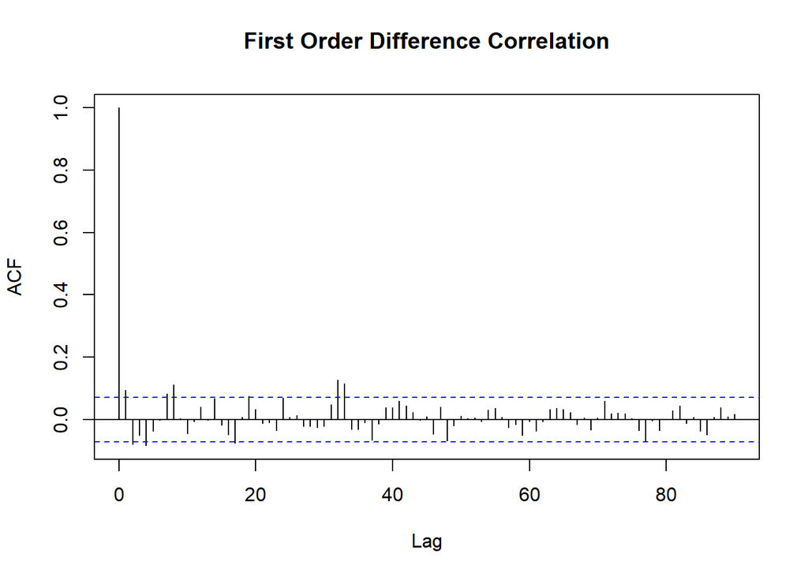

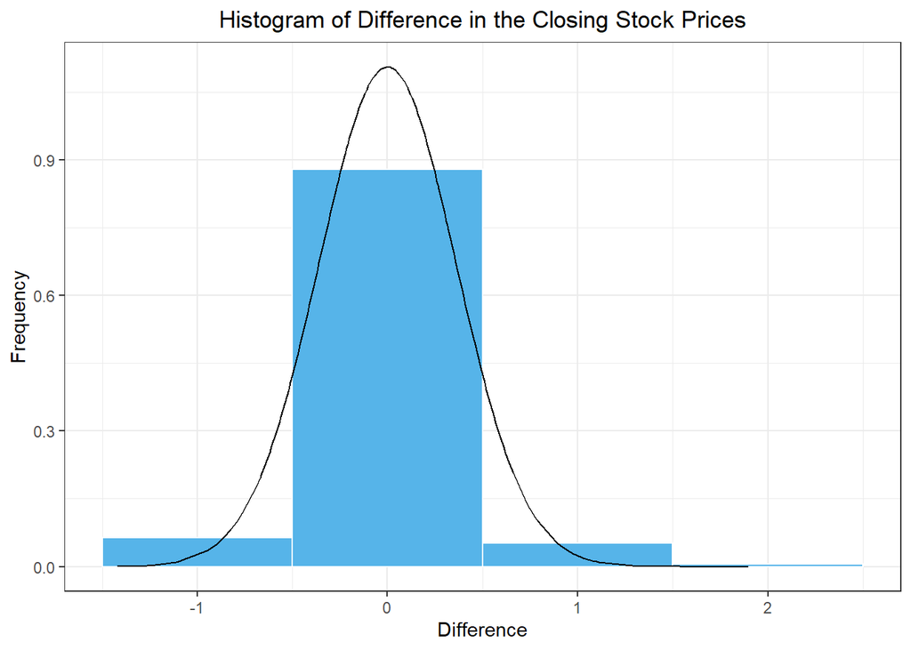

```r
acf(na.omit(stock_ts$diff), plot = TRUE, type = "correlation", lag.max = 90,
    main = "First Order Difference Correlation")
stock_ts |>
  mutate(
    density = dnorm(diff, mean(stock_ts$diff, na.rm = TRUE), sd(stock_ts$diff, na.rm = TRUE))
  ) |>
  ggplot(aes(x = diff)) +
    geom_histogram(aes(y = after_stat(density)),
        color = "white", fill = "#56B4E9", binwidth = 1) +
    geom_line(aes(x = diff, y = density)) +
    theme_bw() +
    labs(
      x = "Difference",
      y = "Frequency",
      title = "Histogram of Difference in the Closing Stock Prices"
    ) +
    theme(
      plot.title = element_text(hjust = 0.5)
    )
```

#### e) Using your results from parts c and d, is there evidence that the first difference of daily closing stock prices follows a white noise process? Please explain.

**Answer**

Based on the correlogram, the first order difference gives strong evidence of white noise. There are a few significant points outside of the confidence interval but we could expect 5% of the data to be outside of those lines and so these do not appear to be practically significant. This shows a lack of significant correlation as would be expected with white noise.

### Question 2 - Random Walks with drift and exponentially weighted slopes: Stocks (20 points)

Using the daily closing stock prices series of the previous question. Can you find evidence that there is drift in the series.

#### a) Please calculate the mean and standard deviation of the first-difference daily closing stock prices series of the previous question.

**Answer**

```r
mean_diff <- stock_ts$diff |> mean(na.rm = TRUE)
sd_diff <- stock_ts$diff |> sd(na.rm = TRUE)

paste("Mean of Differences: ", mean_diff)
```

```
[1] "Mean of Differences:  -0.000372341338624345"
```

```r
paste("Stan. Dev of Differences: ", sd_diff)
```

```
[1] "Stan. Dev of Differences:  0.360869152826884"
```

#### b) Please provide statistical evidence for the need to include a drift component in our random walk model.

**Answer**

```r
t.test(stock_ts$diff, conf.level = 0.95)
```

```
    One Sample t-test

data:  stock_ts$diff
t = -0.028294, df = 751, p-value = 0.9774
alternative hypothesis: true mean is not equal to 0
95 percent confidence interval:
 -0.02620621  0.02546153
sample estimates:
    mean of x
-0.0003723413
```

#### c) Based on the results, is there a justification to adding an exponentially weighted slope vs adding a drift parameter? Please explain.

**Answer**

The 95% confidence interval contains 0, and so it can not be concluded that there is evidence of a positive drift in the price of Sofi. Because the process seems random, adding an exponentially weighted slope isn’t a good idea—it would likely pick up short, term random changes instead of a consistent, predictable trend.

### Rubric

[output not shown]